# Class 4 - In class exercises

Hari Subhash

Date created: 2019-03-19

**CHEATSHEETS**

1. [Data visualization](https://github.com/rstudio/cheatsheets/blob/master/data-visualization-2.1.pdf)
2. [Data Manipulation](https://github.com/rstudio/cheatsheets/blob/master/data-transformation.pdf)

**KEYBOARD SHORTCUTS**:

1. Assignment operator (<-) is `Alt+-` for Windows and `Option+-` for Mac
2. Insert new code chunk `Ctrl+Alt+I` for Windows and `Command+Option+I` for Mac
3. Run a line of code `Ctrl+Enter` for Windows and `Command+Enter` for Mac
4. Run all the code within a chunk `Ctrl+Shift+Enter` for Windows and `Command+Shift+Enter` for Mac
5. Insert a pipe operator (%>%) `Ctrl+Shift+M` for Windows and `Command+Shift+M` for Mac

## Task Set 1: Recap + Factors

1. Filter all departure delays that were between 10 and 20 minutes from LGA in 2013

```r
library(tidyverse); library(nycflights13)
flights %>%
  filter(dep_delay <= 20 & dep_delay >= 10 & origin == 'LGA')
```

| year | month | day | dep_time | sched_dep_time | dep_delay | arr_time | sched_arr_time | arr_delay | carrier | flight | tailnum | origin | dest | air_time | distance | hour | minute | time_hour |
| --- | --- | --- | --- | --- | --- | --- | --- | --- | --- | --- | --- | --- | --- | --- | --- | --- | --- | --- |
| 2013 | 1 | 1 | 623 | 610 | 13 | 920 | 915 | 5 | AA | 1837 | N3EMAA | LGA | MIA | 153 | 1096 | 6 | 10 | 2013-01-01 06:00:00 |
| 2013 | 1 | 1 | 1011 | 1001 | 10 | 1133 | 1128 | 5 | EV | 5736 | N820AS | LGA | IAD | 59 | 229 | 10 | 1 | 2013-01-01 10:00:00 |
| 2013 | 1 | 1 | 1123 | 1110 | 13 | 1410 | 1336 | 34 | UA | 405 | N587UA | LGA | DEN | 256 | 1620 | 11 | 10 | 2013-01-01 11:00:00 |
| 2013 | 1 | 1 | 1343 | 1330 | 13 | 1658 | 1640 | 18 | AA | 753 | N3CFAA | LGA | DFW | 235 | 1389 | 13 | 30 | 2013-01-01 13:00:00 |
| 2013 | 1 | 1 | 1422 | 1410 | 12 | 1613 | 1555 | 18 | MQ | 4491 | N737MQ | LGA | CLE | 93 | 419 | 14 | 10 | 2013-01-01 14:00:00 |
| 2013 | 1 | 1 | 1511 | 1500 | 11 | 1753 | 1742 | 11 | DL | 2347 | N678DL | LGA | ATL | 135 | 762 | 15 | 0 | 2013-01-01 15:00:00 |
| 2013 | 1 | 1 | 1536 | 1520 | 16 | 1709 | 1650 | 19 | WN | 2081 | N226WN | LGA | MKE | 133 | 738 | 15 | 20 | 2013-01-01 15:00:00 |
| 2013 | 1 | 1 | 1610 | 1555 | 15 | 1852 | 1834 | 18 | DL | 1939 | N362NW | LGA | DEN | 235 | 1620 | 15 | 55 | 2013-01-01 15:00:00 |
| 2013 | 1 | 1 | 1652 | 1640 | 12 | 2030 | 1955 | 35 | AA | 773 | N565AA | LGA | DFW | 252 | 1389 | 16 | 40 | 2013-01-01 16:00:00 |
| 2013 | 1 | 1 | 1815 | 1805 | 10 | 1928 | 1920 | 8 | WN | 731 | N266WN | LGA | BWI | 46 | 185 | 18 | 5 | 2013-01-01 18:00:00 |

[output cut: 990 more lines]

2. Use `group_by()` and `filter()` to find the flights that had the greatest delay for each month in 2013.

```r
flights %>%
  group_by(month) %>%
    filter(dep_delay == max(dep_delay, na.rm = T)) %>%
      arrange(month)
```

| year | month | day | dep_time | sched_dep_time | dep_delay | arr_time | sched_arr_time | arr_delay | carrier | flight | tailnum | origin | dest | air_time | distance | hour | minute | time_hour |
| --- | --- | --- | --- | --- | --- | --- | --- | --- | --- | --- | --- | --- | --- | --- | --- | --- | --- | --- |
| 2013 | 1 | 9 | 641 | 900 | 1301 | 1242 | 1530 | 1272 | HA | 51 | N384HA | JFK | HNL | 640 | 4983 | 9 | 0 | 2013-01-09 09:00:00 |
| 2013 | 2 | 10 | 2243 | 830 | 853 | 100 | 1106 | 834 | F9 | 835 | N203FR | LGA | DEN | 233 | 1620 | 8 | 30 | 2013-02-10 08:00:00 |
| 2013 | 3 | 17 | 2321 | 810 | 911 | 135 | 1020 | 915 | DL | 2119 | N927DA | LGA | MSP | 167 | 1020 | 8 | 10 | 2013-03-17 08:00:00 |
| 2013 | 4 | 10 | 1100 | 1900 | 960 | 1342 | 2211 | 931 | DL | 2391 | N959DL | JFK | TPA | 139 | 1005 | 19 | 0 | 2013-04-10 19:00:00 |
| 2013 | 5 | 3 | 1133 | 2055 | 878 | 1250 | 2215 | 875 | MQ | 3744 | N523MQ | EWR | ORD | 112 | 719 | 20 | 55 | 2013-05-03 20:00:00 |
| 2013 | 6 | 15 | 1432 | 1935 | 1137 | 1607 | 2120 | 1127 | MQ | 3535 | N504MQ | JFK | CMH | 74 | 483 | 19 | 35 | 2013-06-15 19:00:00 |
| 2013 | 7 | 22 | 845 | 1600 | 1005 | 1044 | 1815 | 989 | MQ | 3075 | N665MQ | JFK | CVG | 96 | 589 | 16 | 0 | 2013-07-22 16:00:00 |
| 2013 | 8 | 8 | 2334 | 1454 | 520 | 120 | 1710 | 490 | EV | 4978 | N758EV | LGA | CLT | 76 | 544 | 14 | 54 | 2013-08-08 14:00:00 |
| 2013 | 9 | 20 | 1139 | 1845 | 1014 | 1457 | 2210 | 1007 | AA | 177 | N338AA | JFK | SFO | 354 | 2586 | 18 | 45 | 2013-09-20 18:00:00 |
| 2013 | 10 | 14 | 2042 | 900 | 702 | 2255 | 1127 | 688 | DL | 502 | N943DL | EWR | ATL | 98 | 746 | 9 | 0 | 2013-10-14 09:00:00 |

[output cut: 2 more lines]

3. Write two lines on why it is important to ungroup a grouped dataset (once your are done with the grouping operations). If you do not ungroup your data, then your subsequent operations on the data set will occur on the aggregated groupings, not the individual data. Grouping is a mutating change.
4. Look at the documentation for `weekdays()`. Use it on the `time_hour` column inside a `mutate()` to create a new column called `dayName` that records the day of the week that a flight took off. Save this new dataset as `flightsWeek`.

```r
flights %>%
  mutate(dayName = weekdays(time_hour)) -> flightsWeek
flightsWeek
```

| year | month | day | dep_time | sched_dep_time | dep_delay | arr_time | sched_arr_time | arr_delay | carrier | flight | tailnum | origin | dest | air_time | distance | hour | minute | time_hour | dayName |
| --- | --- | --- | --- | --- | --- | --- | --- | --- | --- | --- | --- | --- | --- | --- | --- | --- | --- | --- | --- |
| 2013 | 1 | 1 | 517 | 515 | 2 | 830 | 819 | 11 | UA | 1545 | N14228 | EWR | IAH | 227 | 1400 | 5 | 15 | 2013-01-01 05:00:00 | Tuesday |
| 2013 | 1 | 1 | 533 | 529 | 4 | 850 | 830 | 20 | UA | 1714 | N24211 | LGA | IAH | 227 | 1416 | 5 | 29 | 2013-01-01 05:00:00 | Tuesday |
| 2013 | 1 | 1 | 542 | 540 | 2 | 923 | 850 | 33 | AA | 1141 | N619AA | JFK | MIA | 160 | 1089 | 5 | 40 | 2013-01-01 05:00:00 | Tuesday |
| 2013 | 1 | 1 | 544 | 545 | -1 | 1004 | 1022 | -18 | B6 | 725 | N804JB | JFK | BQN | 183 | 1576 | 5 | 45 | 2013-01-01 05:00:00 | Tuesday |
| 2013 | 1 | 1 | 554 | 600 | -6 | 812 | 837 | -25 | DL | 461 | N668DN | LGA | ATL | 116 | 762 | 6 | 0 | 2013-01-01 06:00:00 | Tuesday |
| 2013 | 1 | 1 | 554 | 558 | -4 | 740 | 728 | 12 | UA | 1696 | N39463 | EWR | ORD | 150 | 719 | 5 | 58 | 2013-01-01 05:00:00 | Tuesday |
| 2013 | 1 | 1 | 555 | 600 | -5 | 913 | 854 | 19 | B6 | 507 | N516JB | EWR | FLL | 158 | 1065 | 6 | 0 | 2013-01-01 06:00:00 | Tuesday |
| 2013 | 1 | 1 | 557 | 600 | -3 | 709 | 723 | -14 | EV | 5708 | N829AS | LGA | IAD | 53 | 229 | 6 | 0 | 2013-01-01 06:00:00 | Tuesday |
| 2013 | 1 | 1 | 557 | 600 | -3 | 838 | 846 | -8 | B6 | 79 | N593JB | JFK | MCO | 140 | 944 | 6 | 0 | 2013-01-01 06:00:00 | Tuesday |
| 2013 | 1 | 1 | 558 | 600 | -2 | 753 | 745 | 8 | AA | 301 | N3ALAA | LGA | ORD | 138 | 733 | 6 | 0 | 2013-01-01 06:00:00 | Tuesday |

[output cut: 990 more lines]

5. Convert this into a factor variable called `fctDayNames` using `factor(flightsWeek$dayName)`. Display it using `table(fctDayNames)`

```r
fctDayNames <- factor(flightsWeek$dayName)
table(fctDayNames)
```

```
fctDayNames
   Friday    Monday  Saturday    Sunday  Thursday   Tuesday Wednesday
    50308     50690     38720     46357     50219     50422     50060
```

```r
table(fctDayNames)
```

```
fctDayNames
   Friday    Monday  Saturday    Sunday  Thursday   Tuesday Wednesday
    50308     50690     38720     46357     50219     50422     50060
```

```r
cleanFctDayNames <- factor(fctDayNames, levels = c("Sunday", "Monday", "Tuesday", "Wednesday", "Thursday", "Friday", "Saturday"), labels = c("Sun", "Mon", "Tue", "Wed", "Thu", "Fri", "Sat"))
table(cleanFctDayNames)
```

```
cleanFctDayNames
  Sun   Mon   Tue   Wed   Thu   Fri   Sat
46357 50690 50422 50060 50219 50308 38720
```

## Task Set 2: Create simple charts

1. Create a histogram of arrival delay.

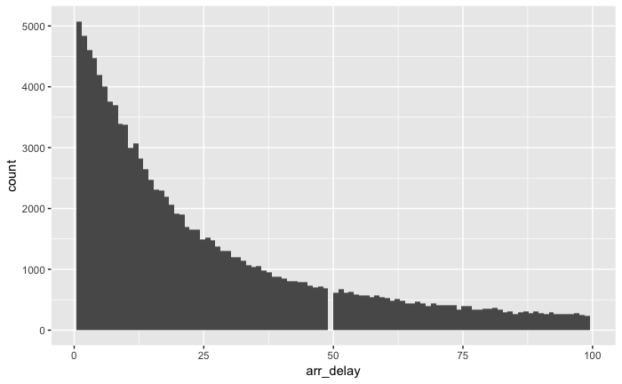

```r
flights %>%
  filter(arr_delay > 0 & arr_delay < 100) %>%
  ggplot(data = ., mapping = aes(arr_delay)) + geom_histogram(bins = 100)
```

2. Change the statistic for the histogram from the default of “count” to “density” and plot again.
3. Run the following code to create a stacked column chart. Look through the documentation and examples for `geom_col()` on the tidyverse portal to fix the code below and create a chart where the bars for each origin are not stacked.

```r
flights %>%
    group_by(origin, month) %>%
    summarise(meanDelay = mean(dep_delay, na.rm = T)) %>%
    ggplot(aes(x = factor(month), y = meanDelay, fill = origin)) +
    geom_col()
```

4. Read the documentation for `geom_point()` to create a scatter plot that compares arrival delay with departure delay. How would you describe the relationship between the two variables?
5. Use the chunk below to group the data by `time_hour` and calculate the mean departure delay and pipe to a ggplot to create a line chart showing `time_hour` on the x-axis and the mean departure delay on the y-axis. Can you identify the spikes in the average delay? Which parts of this would you zoom into to get a better sense for the average delay?

## Task Set 2: Facets and multiple geoms

1. Create a facetted version of any of the two histograms you made in the previous task set. You can pick a facet of your choice (remember that a facet should be a categorical variable)
2. The code below is the same as task 3 in the previous task set. Modify it to create a facetted version of the chart (instead of the stacked bars).

```r
flights %>%
    group_by(origin, month) %>%
    summarise(meanDelay = mean(dep_delay, na.rm = T)) %>%
    ggplot(aes(x = factor(month), y = meanDelay, fill = origin)) +
    geom_col()
```

3. Extend the scatter plot you made in the previous section by adding a `geom_smooth()` to it that uses a linear model (method = “lm”).

## Task Set 3: Make a pretty plot

1. Take any plot that you made in any of the previous set of tasks and
   - Add axis labels and chart title
   - Any additional aesthetics to make it prettier
   - Choose a theme template (either from ggthemes or from ggplot)
   - Make any additional changes you would like to make it more attractive
2. Save this plot using `ggsave()` as a png and share it on the class4 channel.